# Graph Theory 3 Trees

ryamada

2020/5/24

## Trees 木

A tree is a connected graph without a cycle. 木はサイクルを持たない連結グラフ。

A connected graph is a graph in which graph distance of any vertex pair is finite.

連結グラフとは、全ての頂点間のグラフ距離が有限であるようなグラフ。

$|E| = |V|- 1$

## Examples of tree grtaphs 木グラフの例

- Pylogeny tree 系統樹
- Dendrogram, hierarchical clustering tree 樹形図, 階層的クラスタリングの樹形図
- Bifurcation tree 分岐図

## Rooted tree and unrooted tree 根のある木と根のない木

When a tree graph is directed and all vertices are reacheable from one vertex, V0, V0 is called the root of the tree and the tree is rooted.

A tree is unrooted when it is undirected.

## Directed and undirected graphs 有向グラフと無向グラフ

When edges of a graph have direction, or one of two vertices of each edge is a starting vertex and the other is an ending vertex, the graph is directed.

When edges are the pair of vertices without order, the graph is undirected.

The adjacendcy matrix of directed graph is asymmetric, or $(i,j) = 1$ then $(j,i) = 0$.

The adjacency matrix of uindirected graph is symmetric, or $(i,j) =1$ then $(j,i) =1$.

## Bifurcation tree 二分岐木

Assume a bifurcation tree that starts from one vertex and repeat two-division 3 times.

１頂点から始まり、２分岐を３回繰り返す二分岐木を考える。

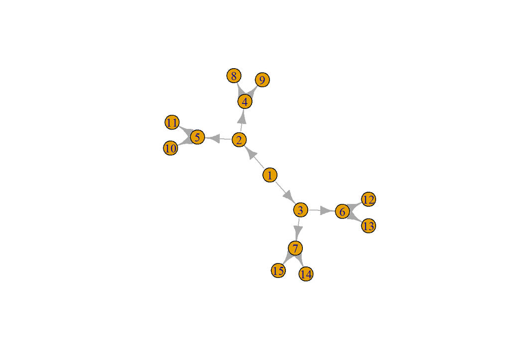

```r
library(igraph)
el <- rbind(c(1,2),c(1,3),c(2,4),c(2,5),c(3,6),c(3,7),c(4,8),c(4,9),c(5,10),c(5,11),c(6,12),c(6,13),c(7,14),c(7,15))

g.bt <- graph.edgelist(el,directed=TRUE)
plot(g.bt)
```

Let’s check that only root vertex V1 can reach all vertices.

全ての頂点に到達できるのは、ルートであるV1であることを示す。

```r
g.dist <- distances(g.bt,mode="out")
g.dist
```

```
##       [,1] [,2] [,3] [,4] [,5] [,6] [,7] [,8] [,9] [,10] [,11] [,12] [,13]
##  [1,]    0    1    1    2    2    2    2    3    3     3     3     3     3
##  [2,]  Inf    0  Inf    1    1  Inf  Inf    2    2     2     2   Inf   Inf
##  [3,]  Inf  Inf    0  Inf  Inf    1    1  Inf  Inf   Inf   Inf     2     2
##  [4,]  Inf  Inf  Inf    0  Inf  Inf  Inf    1    1   Inf   Inf   Inf   Inf
##  [5,]  Inf  Inf  Inf  Inf    0  Inf  Inf  Inf  Inf     1     1   Inf   Inf
##  [6,]  Inf  Inf  Inf  Inf  Inf    0  Inf  Inf  Inf   Inf   Inf     1     1
##  [7,]  Inf  Inf  Inf  Inf  Inf  Inf    0  Inf  Inf   Inf   Inf   Inf   Inf
##  [8,]  Inf  Inf  Inf  Inf  Inf  Inf  Inf    0  Inf   Inf   Inf   Inf   Inf
##  [9,]  Inf  Inf  Inf  Inf  Inf  Inf  Inf  Inf    0   Inf   Inf   Inf   Inf
## [10,]  Inf  Inf  Inf  Inf  Inf  Inf  Inf  Inf  Inf     0   Inf   Inf   Inf
## [11,]  Inf  Inf  Inf  Inf  Inf  Inf  Inf  Inf  Inf   Inf     0   Inf   Inf
## [12,]  Inf  Inf  Inf  Inf  Inf  Inf  Inf  Inf  Inf   Inf   Inf     0   Inf
## [13,]  Inf  Inf  Inf  Inf  Inf  Inf  Inf  Inf  Inf   Inf   Inf   Inf     0
## [14,]  Inf  Inf  Inf  Inf  Inf  Inf  Inf  Inf  Inf   Inf   Inf   Inf   Inf
```

[output cut: 17 more lines]

```r
apply(g.dist,1,sum) # 1st element is finite and all the others are infinite
```

```
##  [1]  34 Inf Inf Inf Inf Inf Inf Inf Inf Inf Inf Inf Inf Inf Inf
```

Check adjacency matrix of this rooted tree (directed graph). It should be asymmetric.

この根のある木(directed graph)の隣接行列を確認する。 非対称行列のはずである。

```r
adj.bt <- get.adjacency(g.bt)
adj.bt
```

```
## 15 x 15 sparse Matrix of class "dgCMatrix"
##
##  [1,] . 1 1 . . . . . . . . . . . .
##  [2,] . . . 1 1 . . . . . . . . . .
##  [3,] . . . . . 1 1 . . . . . . . .
##  [4,] . . . . . . . 1 1 . . . . . .
##  [5,] . . . . . . . . . 1 1 . . . .
##  [6,] . . . . . . . . . . . 1 1 . .
##  [7,] . . . . . . . . . . . . . 1 1
##  [8,] . . . . . . . . . . . . . . .
##  [9,] . . . . . . . . . . . . . . .
## [10,] . . . . . . . . . . . . . . .
## [11,] . . . . . . . . . . . . . . .
## [12,] . . . . . . . . . . . . . . .
## [13,] . . . . . . . . . . . . . . .
## [14,] . . . . . . . . . . . . . . .
## [15,] . . . . . . . . . . . . . . .
```

```r
adj.bt2 <- as.matrix(adj.bt)
adj.bt2 - t(adj.bt2) # if symmetric, all elements are 0.
```

```
##       [,1] [,2] [,3] [,4] [,5] [,6] [,7] [,8] [,9] [,10] [,11] [,12] [,13]
##  [1,]    0    1    1    0    0    0    0    0    0     0     0     0     0
##  [2,]   -1    0    0    1    1    0    0    0    0     0     0     0     0
##  [3,]   -1    0    0    0    0    1    1    0    0     0     0     0     0
##  [4,]    0   -1    0    0    0    0    0    1    1     0     0     0     0
##  [5,]    0   -1    0    0    0    0    0    0    0     1     1     0     0
##  [6,]    0    0   -1    0    0    0    0    0    0     0     0     1     1
##  [7,]    0    0   -1    0    0    0    0    0    0     0     0     0     0
##  [8,]    0    0    0   -1    0    0    0    0    0     0     0     0     0
##  [9,]    0    0    0   -1    0    0    0    0    0     0     0     0     0
## [10,]    0    0    0    0   -1    0    0    0    0     0     0     0     0
## [11,]    0    0    0    0   -1    0    0    0    0     0     0     0     0
## [12,]    0    0    0    0    0   -1    0    0    0     0     0     0     0
## [13,]    0    0    0    0    0   -1    0    0    0     0     0     0     0
## [14,]    0    0    0    0    0    0   -1    0    0     0     0     0     0
```

[output cut: 17 more lines]

```r
range(adj.bt2 - t(adj.bt2)) # if symmetric, it returns from 0 to 0.
```

```
## [1] -1  1
```

Convert this rooted tree to un-rooted tree.

この根のある木を根のない木に変える。

Convert its asymmetric adjacency matrix to a symmetric one. 非対称な隣接行列を対称な隣接行列にすれば良い。

```r
adj.unrooted <- adj.bt2 + t(adj.bt2)
adj.unrooted
```

```
##       [,1] [,2] [,3] [,4] [,5] [,6] [,7] [,8] [,9] [,10] [,11] [,12] [,13]
##  [1,]    0    1    1    0    0    0    0    0    0     0     0     0     0
##  [2,]    1    0    0    1    1    0    0    0    0     0     0     0     0
##  [3,]    1    0    0    0    0    1    1    0    0     0     0     0     0
##  [4,]    0    1    0    0    0    0    0    1    1     0     0     0     0
##  [5,]    0    1    0    0    0    0    0    0    0     1     1     0     0
##  [6,]    0    0    1    0    0    0    0    0    0     0     0     1     1
##  [7,]    0    0    1    0    0    0    0    0    0     0     0     0     0
##  [8,]    0    0    0    1    0    0    0    0    0     0     0     0     0
##  [9,]    0    0    0    1    0    0    0    0    0     0     0     0     0
## [10,]    0    0    0    0    1    0    0    0    0     0     0     0     0
## [11,]    0    0    0    0    1    0    0    0    0     0     0     0     0
## [12,]    0    0    0    0    0    1    0    0    0     0     0     0     0
## [13,]    0    0    0    0    0    1    0    0    0     0     0     0     0
## [14,]    0    0    0    0    0    0    1    0    0     0     0     0     0
```

[output cut: 17 more lines]

```r
range(adj.unrooted - t(adj.unrooted))
```

```
## [1] 0 0
```

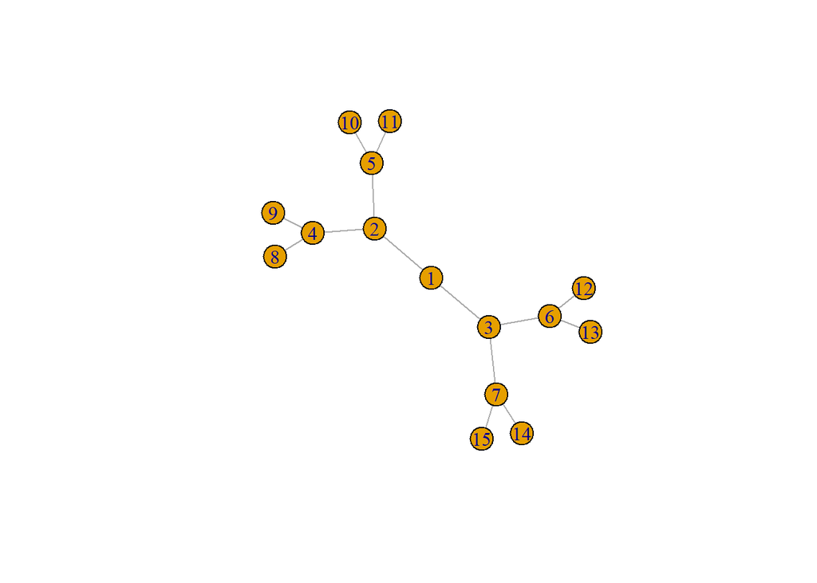

```r
g.bt.unroot <- graph.adjacency(adj.unrooted, mode="undirected")
plot(g.bt.unroot)
```